# [IPO4] Latent Class Analysis (LCA)

> I tried a couple of solutions in R, but none of the Latent Class Analyses / Mixture modeling provided the solution that MPlus did. Therefore in order to be on the absolute safe side and to comply with publishing standards I decided to run the analyses in MPlus, and then transfer the results to R.  
> This is the code I used to export data:  
> #IPO_scales_sum <- data.frame(IPO_scales_sum)  
> #library(MplusAutomation)  
> #prepareMplusData(IPO_scales_sum, “/home/aniko/R/IPO/IPOscalesMplus_mean2.dat”)

## MPlus model specifications

You can check the [final MPlus output (and input) here](http://anikomaraz.com/wp-content/uploads/2017/02/FINAL_lca_ipo_3f_3class_javitott2.txt). Note that the order of the classes is arbitrary, but you should get the same fit indices (just a different class order) when running the input.

I ran 3 models (MPlus specification set to *Type:mixture*, using default settings):  
- Model 1: using the item summary of 5 factors (5F_sum)  
- Model 2: using the mean of 5 factors (5F_mean) (just to test what happens if I use scale means instead of totals)  
- Model 3: using the mean of 3 (primary) factors (3F)  
Each model tested a 2-5 class solution.

```r
# import fit indices of the 3X4 models:
lca_fit <- read.csv("~/R/IPO/data/lca_mplus_fit.csv", header=T, sep = ",")
lca_fit <- data.frame(lca_fit, stringsAsFactors = F)
lca_fit <- plyr:: rename(lca_fit, c("X"= "class", "X.1" = "model"))
print(lca_fit)
```

```
       class   model      AIC      BIC    SSAIC ENTROPY     LMR  LMR.p
1  2_classes  5F_sum 6512.400 6563.700 6513.000   0.876 341.600 0.0353
2  2_classes 5F_mean 1379.600 1430.900 1380.200   0.876 341.600 0.0353
3  2_classes      3F  902.300  934.322  902.700   0.794 167.700 0.0081
4  3_classes  5F_sum 6391.400 6461.800 6392.200   0.912 128.950 0.1548
5  3_classes 5F_mean 1258.540 1329.030 1259.350   0.912 128.960 0.1553
6  3_classes      3F  840.233  885.012  840.673   0.830  65.160 0.0081
7  4_classes  5F_sum 6329.620 6419.300 6330.650   0.843  71.450 0.3800
8  4_classes 5F_mean 1196.760 1286.500 1197.800   0.843  71.450 0.3800
9  4_classes      3F  820.400  878.100  821.100   0.797  31.680 0.5247
10 5_classes  5F_sum 6291.600 6400.500 6292.800   0.867  48.500 0.0621
11 5_classes 5F_mean 1158.740 1267.700 1160.000   0.867  48.500 0.0621
12 5_classes      3F  800.200  870.700  801.000   0.812  26.921 0.0532
```

If you are unfamiliar with latent class fit indices, use [this link](http://davidakenny.net/cm/fit.htm) for a good interpretation of fit indices.

Based on AIC, BIC and SSAIC models with a higher number of classes seems to fit better, but the difference is not substantial. However, fit indices clearly imply that the model with 3 factors is superior to 5 factors, which is also in line with the initial theoretical model which described the first 3 factors as “primary”, and the remaining 2 as “additional”. The first non-significant LMR value is at 4 classes (p=0.5247), so the 3 classes model with 3 factors seems to fit the best. Entropy is still acceptable (0.83, has to be >0.8).

Note, that the final, 3-class solution did not reach local maxima, and had excellent absolute and relative fit indices. Average class assignment probabilities were 0.92, 0.91 and 0.94 respectively for the classes (Class 1=“Well-integrated”, Class 2 = “Disintegrated”, Class 3 = “Moderately integrated”) (they should be >0.80)

## Read the MPlus output (including class membership) in R

```r
lca_class <- read.table("~/R/IPO/data/lca_membership.txt",
                        col.names=c("PPD", "RT", "ID", "cprob1", "cprob2", "cprob3", "lca_class"))
head(lca_class)
```

```
    PPD    RT   ID cprob1 cprob2 cprob3 lca_class
1 4.438 3.714 3.50  0.000  1.000  0.000         2
2 3.312 3.000 3.05  0.000  0.169  0.831         3
3 3.438 3.333 2.15  0.000  0.096  0.904         3
4 3.000 2.667 1.75  0.037  0.000  0.963         3
5 3.438 2.571 1.65  0.009  0.000  0.990         3
6 2.875 3.190 2.80  0.000  0.013  0.987         3
```

“cprob” columns contain the probability of the given row (patient) belonging to the given class. I could use this for the remaining calculations (especially group differences using Wald test), but classes are homogenous enough to be treated as separate groups.

## Plot class means

```r
library(reshape2)
prim_factors <- c("PPD", "RT", "ID", "lca_class") #based on primary factors only
lca_class_factors <- lca_class[prim_factors]
lca_class_melt <- melt(lca_class_factors, id="lca_class")

library(Rmisc)
lca_plot <- summarySE(lca_class_melt, measurevar=c("value"), groupvars=c("lca_class", "variable"))
lca_plot$lca_class <- as.factor(lca_plot$lca_class)
lca_plot$lca_class <- factor(lca_plot$lca_class,
                               levels=c("2", "3", "1"),
                               labels = c("Disintegrated (n=23)",
                                          "Moderately integrated (n=91)",
                                          "Well-integrated (n=67)"))
table(lca_class$lca_class) ## there are N=67, N=23 and N=91 participants in each class, which sums up to 181.
```

```
 1  2  3
67 23 91
```

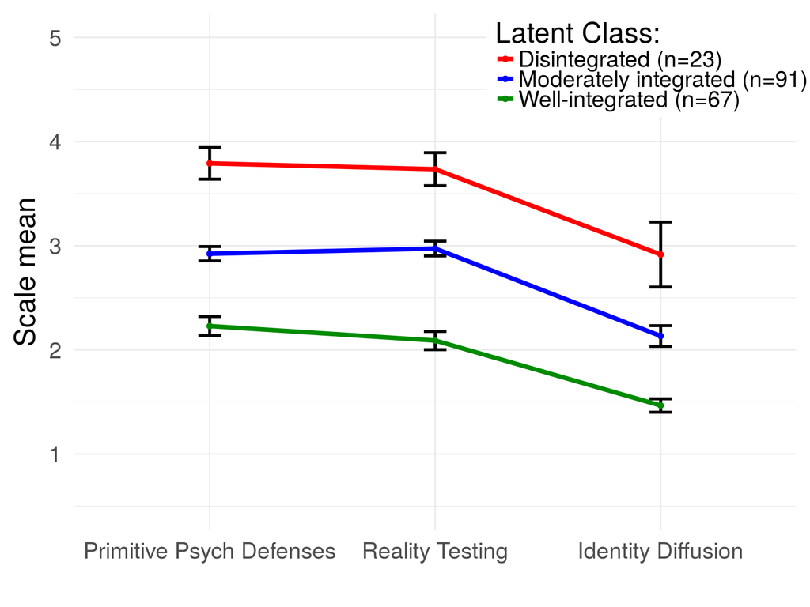

```r
library(ggplot2)
ggplot(lca_plot, aes(x=variable, y=value, color=lca_class, group=lca_class)) +
    coord_cartesian(ylim=c(0.5,5)) +
    geom_errorbar(aes(ymin=value-ci, ymax=value+ci), color="black", width=.1, size=1) +
    geom_line(size=1.5) +
    geom_point(size=1.5) +
    theme_minimal(base_size=20) +
    scale_colour_manual(values = c("red", "blue","green4")) +
    labs(y="Scale mean", x="", color="Latent Class: ") +
  scale_x_discrete(labels=c(
    "PPD" = "Primitive Psych Defenses",
    "RT" = "Reality Testing",
    "ID" = "Identity Diffusion")) +
  theme(legend.position= c(0.8, 0.9),
        legend.background = element_rect(colour="white"),
        legend.key.size = unit(0.5, "cm"))
```

Classes are nicely separated and appear to be homogeneous.